suppl data 9: long binary lists of interactors per experiment, including combined networks across time points and index proteins

# analysis

These analyses focus on overlaps

## plot network and overlaps as force directed graphs

prepare lists with different IP replicates of the same index protein

prepare lists of networks combined across replicates for each index protein

### plot overlaps between different replicates of the same index protein

prepare links and nodes

plot different replicates of CACNA1C

[interactive chart not shown]

plot different replicates of HCN1

[interactive chart not shown]

plot different replicates of SYNGAP1

[interactive chart not shown]

### plot overlaps between combined networks

prepare links and nodes

[interactive chart not shown]

## investigate effects of different fold-change cutoffs

Given the large differences in the number of detected interactors when using the same index at the same week timepoint, plot the network size as a function of FC cut-off to check for whether there a ‘shoulder’ in the distribution of network size.

From the manuscript: “.. defining proteins with log2 FC > 0 and FDR ≤ 0.1 as the significant interactors of the index protein.” ([Hsu et al., 2022, p. 8])”

load data

add ‘experiment’ and ‘index’ columns

### how does fold-change FDR cutoff affect total number of interactors?

select cutoff by 1. adding together all experiments 2. taking point where distance between observed and expected combined network size (KS-stat) is maximized, where expected assumes a uniform distribution of interactor FDR p-values

> [!info] Note that we should probably consider re-computing FDR values! However we are using FDR values simply as a measure of association, not for inference)

```
[1] "optimal cutoff:0.017"
```

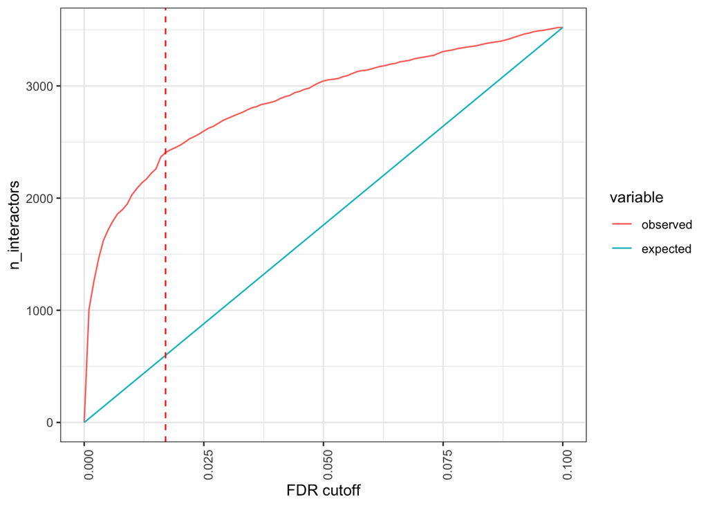

### how does FDR cutoff affects the mean degree of an interactor?

NB: do not filter networks with a more stringent FDR cutoff using the approach of the previous section. This is a separate analysis to see how FDR affects the index-degree of interactors (i.e. the number of different index proteins for which the same interactor comes up)

define plot function

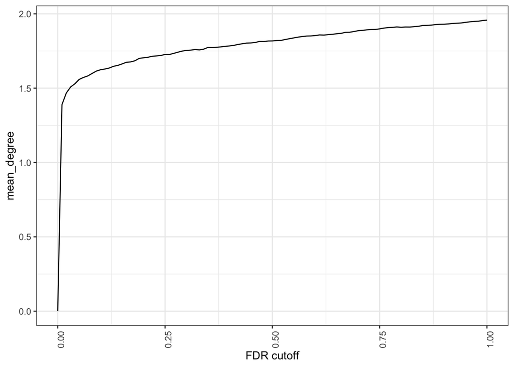

The mean degree of interactors rises quickly initially, then slower as we raise FDR cutoff This suggests that the overlap is not noise, since reoccurring interactors tend to have highly significant FC FDR p-values

#### what is the relationship between an interactor’s mean (across indices) minimum (across replicates) FDR, and the number of indexes for which it comes up?

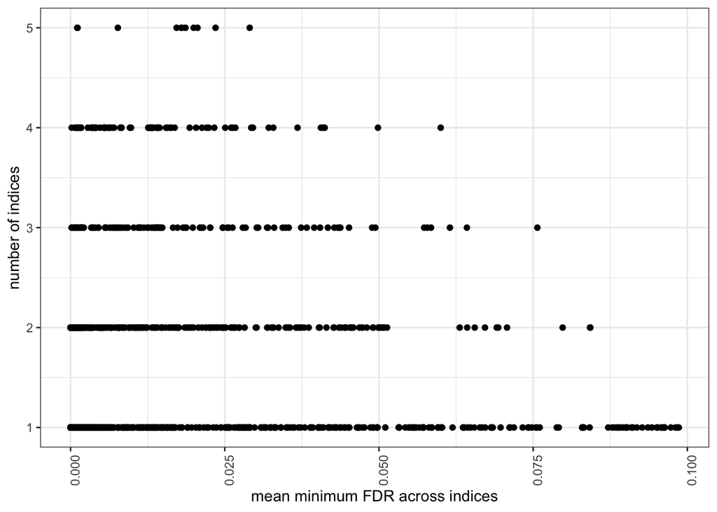

When we look at the proteins with non-negative logFC and FDR p-values < 0.1, we see that the interactors with an FDR < 0.1 that occur across most indices tend to have a low (highly statistically significant) FDR.

This may suggest that there is a set of interactors that are robustly shared across the index proteins.

What are these hub interactors?

| gene | mean_min_FDR |
| --- | --- |
| ATP6V0A1 | 0.001075228 |
| PLXNA4 | 0.001136194 |
| SYT11 | 0.007663267 |
| VDAC2 | 0.017190651 |
| CAMK2G | 0.017947213 |
| SRCIN1 | 0.018063047 |
| CAMK2B | 0.018629245 |
| CNTNAP1 | 0.019951375 |
| CAMK2D | 0.020580073 |
| RAB3A | 0.023503440 |

[output cut: 1 more lines]

None of the index genes are hub genes.

## PRS analyses

prepare data for PRS analyses of overlaps

next steps (done outside this script): investigate PRS of overlaps * interactors with degree = 5 * every subset of interactors with degree = 4 * every subset of interactors with degree = 3 * every subset of interactors with degree = 2 * every subset of interactors with degree = 1